# Klasyfikacja klientów banku pod względem rezygnacji z posiadania karty kredytowej

- Pokaż cały kod
- Ukryj cały kod
- Pokaż źródło

Projekt zaliczeniowy - Eksploracja Danych

Autor

Instytucja

Szymon Olędzki

Politechnika Lubelska

> Kiedy diabeł idzie Wall Street, rogi mu przykrywa czarny melonik, miast kopytami dla niepoznaki stuka srebrną laską, a ogon ma z kart kredytowych.

> — Andrzej Majewski

# Karty kredytowe w USA

W 1958 roku Bank of America wprowadził na rynek nowość, która okazała się kamieniem milowym w rozwoju nowoczesnej bankowości. Do 60 tys. klientów mieszkających we Fresno w Kalifornii trafiły gotowe do użycia karty noszące znak BankAmericard. Chociaż idea bezgotówkowych zakupów na kredyt nie była już wówczas innowacją, to test przeprowadzony 60 lat temu opierał się na nowym pomyśle.

Karty BankAmericard mogły być używane w każdej placówce handlowej, niezależnie od branży. Wcześniej na amerykańskim rynku królowały karty obciążeniowe o ograniczonych zastosowaniach. Można było nimi płacić w restauracjach, hotelach albo wybranych sieciach handlowych.

Drugą nowinką była formuła spłaty zadłużenia – odnawialny limit. Wystarczyło spłacić część długu, by móc od nowa korzystać z plastiku na zakupach. Spłata zadłużenia w terminie w całości pozwalała korzystać z okresu bezodsetkowego, czyli pożyczać środki bez ponoszenia kosztów.

Rynkowy test z 1958 roku okazał się sukcesem. Już dwa lata później w portfelach Amerykanów znalazł się milion kredytówek, a Bank of America zaczął wydawać licencje na swoje karty. Inne banki mogły dołączyć do schematu jako wydawcy. Takie były narodziny giganta na rynku kart płatniczych – organizacji znanej dziś pod nazwą Visa. (za Bankier.pl 2018)

Obecnie coraz więcej Amerykanów w każdym wieku zaczyna mieć problemy z regularnym płaceniem rachunków, zwłaszcza ze spłacaniem kart kredytowych. Dzieje się to w momencie kiedy akcje na Wall Street osiągają historyczne maksima, a bezrobocie pozostaje na niezwykle niskim poziomie.

Zgodnie z danymi Banku Rezerw Federalnych w przypadku długów, poza kredytami studenckimi, wskaźniki spłacalności od pandemii koronawirusa maleją. Teraz zaległości z tytułu kart kredytowych przekroczyły poziom sprzed COVID-19 i wciąż rosną. Np. te, których termin spłaty minął 90 dni temu, osiągnęły poziom 10,7 proc. To najwyższy poziom od 2012 roku. (za Bankier.pl 2024)

# Problem badawczy

Celem niniejszego projektu jest budowa optymalnego modelu klasyfikacyjnego, którego zadaniem będzie predykcja, czy dany klient banku zrezygnuje z posiadania karty kredytowej. Zagadnienie to jest biznesowo istotne dla możliwie skutecznego przeciwdziałania procesowi utraty klientów.

# Zbiór danych

Zbiór danych Credit Card Churn Prediction pochodzi z serwisu Kaggle (San 2022). Zawiera informacje o 10127 klientach banku, dla których na podstawie 19 zmiennych określono fakt posiadania karty kredytowej - jest to 20 zmienna w zbiorze. Pozostałe 3 zmienne w zbiorze nie będą istotne dla dalszej analizy.

## Przygotowanie danych do dalszej pracy

Zbiór nie zawiera braków danych. Koniecznym działaniem przed rozpoczęciem dalszej pracy jest usunięcie zbędnych kolumn z pierwotnego zbioru. Są to `CLIENTNUM`, czyli zmienna dla numeru identyfikacyjnego klienta oraz dwie zmienne, których usunięcie zaleca autor zbioru.

Ponadto koniecznym krokiem jest zmiana typów danych na odpowiedni dla każdej zmiennej, dla zmiennych porządkowych razem z poprawnym uwzględnieniem kolejności poziomów.

## Charakterystyka zmiennych

**Zmienne jakościowe**

1. `Attrition_Flag` - *zmienna binarna* opisująca status klienta banku, jest to **zmienna zależna**, przyjmuje 2 wartości:
   - `Existing Customer` - klient aktywny
   - `Attrited Customer` - klient utracony

[interactive chart not shown]

Rysunek 1: Liczba klientów według statusu klienta

2. `Gender` - *zmienna binarna* opisująca płeć klienta, przyjmuje 2 wartości:
   - `F` - kobieta
   - `M` - mężczyzna

**Wykres słupkowy**

[interactive chart not shown]

Rysunek 2: Liczba klientów według płci

**Według zmiennej zależnej**

[interactive chart not shown]

Rysunek 3: Liczba klientów według płci i statusu klienta

3. `Marital_Status` - *zmienna jakościowa* opisująca stan cywilny klienta, przyjmuje 4 wartości:
   - `Single` - samotny
   - `Married` - pozostający w związku małżeńskim
   - `Divorced` - rozwiedziony
   - `Unknown` - nieznany

**Wykres słupkowy**

[interactive chart not shown]

Rysunek 4: Liczba klientów według stanu cywilnego

**Według zmiennej zależnej**

[interactive chart not shown]

Rysunek 5: Liczba klientów według stanu cywilnego i statusu klienta

**Zmienne porządkowe**

1. `Education_Level` - *zmienna porządkowa* opisująca wykształcenie klienta, przyjmuje 7 wartości:
   - `Unknown` - nieznane
   - `Uneducated` - brak wykształcenia
   - `High School` - szkoła średnia
   - `College` - studia wyższe bez tytułu
   - `Graduate` - studia licencjackie
   - `Post-Graduate` - studia podyplomowe
   - `Doctorate` - doktorat

**Wykres słupkowy**

[interactive chart not shown]

Rysunek 6: Liczba klientów według wykształcenia

**Według zmiennej zależnej**

[interactive chart not shown]

Rysunek 7: Liczba klientów według wykształcenia i statusu klienta

2. `Income_Category` - *zmienna porządkowa* opisująca roczny przychód klienta, przyjmuje 6 wartości:
   - `Less than $40K` - poniżej 40 tys. dolarów
   - `$40K - $60K` - między 40, a 60 tys. dolarów
   - `$60K - $80K` - między 60, a 80 tys. dolarów
   - `$80K - $120K` - między 80, a 120 tys. dolarów
   - `$120K +` - powyżej 120 tys. dolarów
   - `Unknown` - nieznany

**Wykres słupkowy**

[interactive chart not shown]

Rysunek 8: Liczba klientów według rocznego dochodu

**Według zmiennej zależnej**

[interactive chart not shown]

Rysunek 9: Liczba klientów według rocznego dochodu i statusu klienta

3. `Card_Category` - *zmienna porządkowa* opisująca rodzaj posiadanej przez klienta karty kredytowej, przyjmuje 4 wartości:
   - `Blue` - niebieska
   - `Silver` - srebrna
   - `Gold` - złota
   - `Platinum` - platynowa

**Wykres słupkowy**

[interactive chart not shown]

Rysunek 10: Liczba klientów według rodzaju karty kredytowej

**Według zmiennej zależnej**

[interactive chart not shown]

Rysunek 11: Liczba klientów według rodzaju karty kredytowej i statusu klienta

**Zmienne ilościowe**

1. `Customer_Age` - *zmienna ilościowa* opisująca wiek klienta

**Histogram**

[interactive chart not shown]

Rysunek 12: Rozkład wieku klientów

**Według zmiennej zależnej**

[interactive chart not shown]

Rysunek 13: Rozkład wieku klientów - klient utracony

[interactive chart not shown]

Rysunek 14: Rozkład wieku klientów - klient aktywny

2. `Dependent_Count` - *zmienna ilościowa* opisująca liczbę osób, które pozostają na utrzymaniu klienta

**Wykres słupkowy**

[interactive chart not shown]

Rysunek 15: Liczba klientów według liczby osób na utrzymaniu klienta

**Według zmiennej zależnej**

[interactive chart not shown]

Rysunek 16: Liczba klientów według liczby osób na utrzymaniu klienta i statusu klienta

3. `Months_on_book` - *zmienna ilościowa* opisująca od ilu miesięcy klient jest związany z bankiem

**Histogram**

[interactive chart not shown]

Rysunek 17: Rozkład liczby miesięcy jako klient

**Według zmiennej zależnej**

[interactive chart not shown]

Rysunek 18: Rozkład liczby miesięcy jako klient - klient utracony

[interactive chart not shown]

Rysunek 19: Rozkład liczby miesięcy jako klient - klient aktywny

4. `Total_Relationship_Count` - *zmienna ilościowa* opisująca z ilu usług banku korzysta dany klient

**Wykres słupkowy**

[interactive chart not shown]

Rysunek 20: Liczba klientów według liczby usług w banku, z których korzysta klient

**Według zmiennej zależnej**

[interactive chart not shown]

Rysunek 21: Liczba klientów według liczby usług w banku, z których korzysta klient i statusu klienta

5. `Months_Inactive_12_mon` - *zmienna ilościowa* opisująca przez ile miesięcy (w ciągu ostatnich 12 miesięcy) klient nie podejmował żadnej aktywności

**Wykres słupkowy**

[interactive chart not shown]

Rysunek 22: Liczba klientów według liczby miesięcy bez aktywności

**Według zmiennej zależnej**

[interactive chart not shown]

Rysunek 23: Liczba klientów według liczby miesięcy bez aktywności i statusu klienta

6. `Contacts_Count_12_mon` - *zmienna ilościowa* opisująca ile razy w ciągu ostatnich 12 miesięcy bank kontaktował się z klientem

**Wykres słupkowy**

[interactive chart not shown]

Rysunek 24: Liczba klientów według liczby kontaktów z klientem

**Według zmiennej zależnej**

[interactive chart not shown]

Rysunek 25: Liczba klientów według liczby kontaktów z klientem i statusu klienta

7. `Credit_Limit` - *zmienna ilościowa* opisująca limit kredytowy na karcie klienta

**Histogram**

[interactive chart not shown]

Rysunek 26: Rozkład limitu kredytowego

**Według zmiennej zależnej**

[interactive chart not shown]

Rysunek 27: Rozkład limitu kredytowego - klient utracony

[interactive chart not shown]

Rysunek 28: Rozkład limitu kredytowego - klient aktywny

8. `Total_Revolving_Bal` - *zmienna ilościowa* opisująca całkowite saldo odnawialne na karcie klienta

**Histogram**

[interactive chart not shown]

Rysunek 29: Rozkład całkowitego salda odnawialnego

**Według zmiennej zależnej**

[interactive chart not shown]

Rysunek 30: Rozkład całkowitego salda odnawialnego - klient utracony

[interactive chart not shown]

Rysunek 31: Rozkład całkowitego salda odnawialnego - klient aktywny

9. `Avg_Open_To_Buy` - *zmienna ilościowa* opisująca średnią różnicę między limitem kredytowym a stanem konta klienta w ciągu ostatnich 12 miesięcy

**Histogram**

[interactive chart not shown]

Rysunek 32: Rozkład limitu kredytowego

**Według zmiennej zależnej**

[interactive chart not shown]

Rysunek 33: Rozkład średniej różnicy między limitem kredytowym a stanem konta klienta w ciągu ostatnich 12 miesięcy - klient utracony

[interactive chart not shown]

Rysunek 34: Rozkład średniej różnicy między limitem kredytowym a stanem konta klienta w ciągu ostatnich 12 miesięcy - klient aktywny

10. `Total_Amt_Chng_Q4_Q1` - *zmienna ilościowa* opisująca zmianę w kwotach dokonywanych transakcji, porównanie 4 kwartału do 1 kwartału.

**Histogram**

[interactive chart not shown]

Rysunek 35: Rozkład zmian w kwotach dokonywanych transakcji

**Według zmiennej zależnej**

[interactive chart not shown]

Rysunek 36: Rozkład zmian w kwotach dokonywanych transakcji - klient utracony

[interactive chart not shown]

Rysunek 37: Rozkład zmian w kwotach dokonywanych transakcji - klient aktywny

11. `Total_Trans_Amt` - *zmienna ilościowa* opisująca sumę dokonanych transakcji z ostatnich 12 miesięcy

**Histogram**

[interactive chart not shown]

Rysunek 38: Rozkład sumy dokonanych transakcji z ostatnich 12 miesięcy

**Według zmiennej zależnej**

[interactive chart not shown]

Rysunek 39: Rozkład sumy dokonanych transakcji z ostatnich 12 miesięcy - klient utracony

[interactive chart not shown]

Rysunek 40: Rozkład sumy dokonanych transakcji z ostatnich 12 miesięcy - klient aktywny

12. `Total_Trans_Ct` - *zmienna ilościowa* opisująca liczbę dokonanych transakcji z ostatnich 12 miesięcy

**Histogram**

[interactive chart not shown]

Rysunek 41: Rozkład liczby dokonanych transakcji z ostatnich 12 miesięcy

**Według zmiennej zależnej**

[interactive chart not shown]

Rysunek 42: Rozkład liczby dokonanych transakcji z ostatnich 12 miesięcy - klient utracony

[interactive chart not shown]

Rysunek 43: Rozkład liczby dokonanych transakcji z ostatnich 12 miesięcy - klient aktywny

13. `Total_Ct_Chng_Q4_Q1` - *zmienna ilościowa* opisująca zmianę w liczbie dokonywanych transakcji, porównanie 4 kwartału do 1 kwartału.

**Histogram**

[interactive chart not shown]

Rysunek 44: Rozkład zmiany liczby dokonanych transakcji z ostatnich 12 miesięcy

**Według zmiennej zależnej**

[interactive chart not shown]

Rysunek 45: Rozkład zmiany liczby dokonanych transakcji z ostatnich 12 miesięcy - klient utracony

[interactive chart not shown]

Rysunek 46: Rozkład zmiany liczby dokonanych transakcji z ostatnich 12 miesięcy - klient aktywny

14. `Avg_Utilization_Ratio` - *zmienna ilościowa* opisująca średni wskaźnik wykorzystania środków z limitu karty kredytowej

**Histogram**

[interactive chart not shown]

Rysunek 47: Rozkład średniego wskaźnika wykorzystania środków z limitu karty kredytowej

**Według zmiennej zależnej**

[interactive chart not shown]

Rysunek 48: Rozkład średniego wskaźnika wykorzystania środków z limitu karty kredytowej - klient utracony

[interactive chart not shown]

Rysunek 49: Rozkład średniego wskaźnika wykorzystania środków z limitu karty kredytowej - klient aktywny

**Uwaga - symetria zmiennych ilościowych**

Brak symetrii wielu zmiennych ilościowych jest istotną informacją przy procesie przygotowania danych dla niektórych modeli uczenia maszynowego.

## Zależności w analizowanym zbiorze danych

### Zmienne ilościowe

Analizę zależności cech rozpocznę od zbadania korelacji r-Pearsona pośród zmiennych ilościowych.

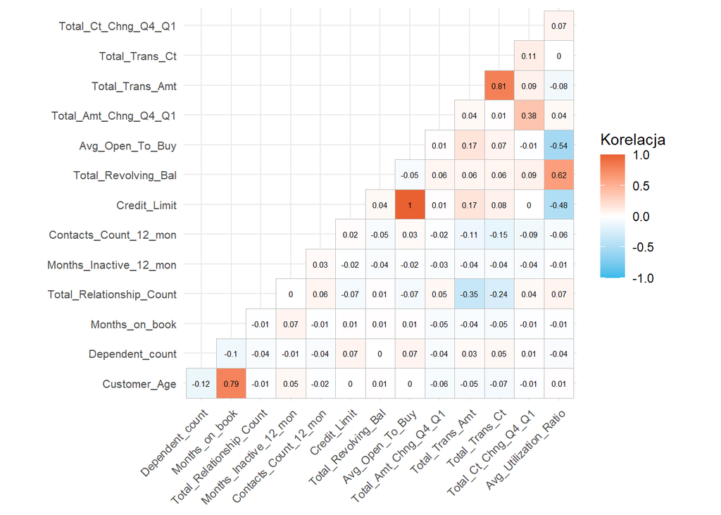

Rysunek 50: Macierz korelacji zmiennych ilościowych

Na podstawie wykresu Rysunek 50 zauważyć można trzy silnie dodatnio skorelowane pary zmiennych:

1. Wiek klienta (`Customer_Age`) oraz liczba miesięcy korzystania z usług banku (`Months_on_book`)
2. Suma (`Total_Trans_Amt`) oraz liczba (`Total_Trans_Ct`) dokonanych w ciągu ostatnich 12 miesięcy transakcji
3. Limit kredytowy na karcie klienta (`Credit_Limit`) oraz średnia różnica między limitem a stanem konta w ciągu ostatnich 12 miesięcy (`Avg_Open_To_Buy`)

Wysokie wartości tych korelacji mają oczywiście sens i bezpośrednie przełożenie na rzeczywistość.

**Uwaga - korelacja zmiennych ilościowych**

Wysokie skorelowanie zmiennych ilościowych jest istotną informacją przy procesie przygotowania danych dla niektórych modeli uczenia maszynowego.

### Zmienne jakościowe

Analizę zależności zmiennych jakościowych rozpoczynam od zbadania zależności wszystkich par cech za pomocą testu $\chi^2$.

Tabela 1: Tabela niezależności dla par cech nominalnych

| Zmienna 1 | Zmienna 2 | p-value | Werdykt |
| --- | --- | --- | --- |
| Attrition_Flag | Gender | 0.00020 | zależne |
| Attrition_Flag | Marital_Status | 0.10891 | niezależne |
| Attrition_Flag | Education_Level | 0.05149 | niezależne |
| Attrition_Flag | Income_Category | 0.02500 | zależne |
| Attrition_Flag | Card_Category | 0.52524 | niezależne |
| Gender | Marital_Status | 0.27524 | niezależne |
| Gender | Education_Level | 0.29498 | niezależne |
| Gender | Income_Category | 0.00000 | zależne |
| Gender | Card_Category | 0.00000 | zależne |
| Marital_Status | Education_Level | 0.25451 | niezależne |
| Marital_Status | Income_Category | 0.31078 | niezależne |
| Marital_Status | Card_Category | 0.00018 | zależne |
| Education_Level | Income_Category | 0.03655 | zależne |
| Education_Level | Card_Category | 0.48034 | niezależne |
| Income_Category | Card_Category | 0.00000 | zależne |

Spośród 15 badanych par, dla 7 z nich odrzucamy hipotezę zerową o niezależności cech.

Następnym krokiem będzie zbadanie siły zależności dla każdej z 7 par, do tego celu wykorzystam współczynnik V-Cramera.

Tabela 2: Tabela siły związku par zmiennych nominalnych, wzajemnie zależnych (na podstawie współczynnika V-Cramera)

| Zmienna 1 | Zmienna 2 | p-value | Werdykt | V-Cramer |
| --- | --- | --- | --- | --- |
| Attrition_Flag | Gender | 0.00020 | zależne | 0.03727 |
| Attrition_Flag | Income_Category | 0.02500 | zależne | 0.03560 |
| Gender | Income_Category | 0.00000 | zależne | 0.83960 |
| Gender | Card_Category | 0.00000 | zależne | 0.08606 |
| Marital_Status | Card_Category | 0.00018 | zależne | 0.03258 |
| Education_Level | Income_Category | 0.03655 | zależne | 0.02990 |
| Income_Category | Card_Category | 0.00000 | zależne | 0.05742 |

Jak się okazuje, tylko w przypadku zmiennych płci (`Gender`) i rocznego dochodu klienta (`Income_Category`) zależność jest naprawdę silna. Pozostałe wartości są istotnie różne od zera, jednak nie pozwalają na wyciągnięcie pożytecznych wniosków. Martwić może jedynie fakt, że żadna ze zmiennych jakościowych nie ma silnego związku ze zmienną zależną, dzięki czemu nie możemy na tym etapie wskazać żadnej z nich jako istotnego predyktora dla problemu badawczego.

[interactive chart not shown]

Rysunek 51: Liczba klientów według rocznego dochodu i płci

Na powyższym wykresie Rysunek 51 można zauważyć, że rzeczywiście zachodzi zależność między płcią, a rocznym dochodem. Jak się okazuje, żadna z byłych i obecnych klientek banku nie zarabia więcej, niż 60 tys. USD rocznie. Widać istotną dysproporcję w poziomie zarobków kobiet i mężczyzn, chociaż różnica w liczbie przedstawicieli każdej z płci nie jest duża. Warto jednak zwrócić uwagę na fakt, że zarobki niemal 20% kobiet pozostają nieznane.

# Ewaluacja modeli uczenia maszynowego

Zmienna zależna w omawianym zbiorze danych jest zmienną typu binarnego - każda z obserwacji może być klientem aktywnym, bądź klientem utraconym. Dziedziną problemu jest zatem klasyfikacja binarna, a w ramach pakietu `parsnip` istnieje wiele implementacji modeli uczenia maszynowego przeznaczonych dla tego typu problemów.

Wybrane przeze mnie rodzaje modeli to:

- Regresja logistyczna z silnikiem `glmnet`
- Drzewo decyzyjne z silnikiem `rpart`
- Las losowy z silnikiem `ranger`
- Boosting z silnikiem `xgboost`
- Bagging z silnikiem `C5.0`
- SVM z jądrem RBF i silnikiem `kernlab`
- MLP z silnikiem `brulee`

Metody te podzieliłem na trzy zestawy przepływów pracy, w zależności od zalecanego preprocessingu[^1].

## Przygotowanie danych do procesu uczenia

Zbiór danych dzielę na zbiory treningowy (80%) oraz testowy (20%) z uwzględnieniem parametru `strata` dla zmiennej zależnej.

Dla każdej z receptur podstawowa formuła jest taka sama i przewiduje zmienną zależną na podstawie wszystkich predyktorów, dodatkowo w każdym przypadku stosuję próbkowanie w dół ze względu na zmienną zależną.

Recepturę podstawową stosuję dla modeli drzewa decyzyjnego, lasu losowego i baggingu.

Następna receptura poszerzona jest o następujące kroki:

- usunięcie zmiennych silnie skorelowanych (domyślnie powyżej 0.9),
- usunięcie zmiennych o zerowej wariancji,
- one-hot encoding dla zmiennych nominalnych

Recepturę stosuję dla modeli regresji logistycznej oraz boostingu.

Ostatnia, najbardziej złożona receptura jest względem poprzedniej poszerzona o dwa dodatkowe kroki:

- transformacja Yeo-Johnsona dla zmiennych ilościowych,
- standaryzacja zmiennych ilościowych

Ostatnią recepturę stosuję dla modeli SVM oraz MLP.

Kolejność kroków dla każdej z receptur oparłem na informacjach znalezionych na oficjalnej stronie pakietu `recipes`[^2].

**Pokaż kod**

```r
set.seed(420)
# Podział na zbiory treningowy i testowy
data_split <- initial_split(data, prop = 0.8, strata = Attrition_Flag)
train_data <- training(data_split)
test_data <- testing(data_split)

# Dla drzewa, lasu i baggingu
simple_recipe <- recipe(Attrition_Flag ~ ., data = train_data) %>%
  step_downsample(Attrition_Flag)

# Dla regresji logistycznej i boostingu z xgboost
middle_recipe <- recipe(Attrition_Flag ~ ., data = train_data) %>%
  step_corr(all_numeric_predictors()) %>%
  step_zv(all_predictors()) %>%
  step_dummy(all_nominal_predictors(), -all_outcomes()) %>%
  step_downsample(Attrition_Flag)

# Dla SVM i MLP
complete_recipe <- recipe(Attrition_Flag ~ ., data = train_data) %>%
  step_corr(all_numeric_predictors()) %>%
  step_zv(all_predictors()) %>%
  step_YeoJohnson(all_numeric_predictors()) %>%
  step_dummy(all_nominal_predictors(), -all_outcomes()) %>%
  step_normalize(all_numeric_predictors()) %>%
  step_downsample(Attrition_Flag)

folds <- vfold_cv(train_data, v = 10, strata = Attrition_Flag)
metrics <- metric_set(accuracy, bal_accuracy, kap, j_index)
```

## Przygotowanie specyfikacji modeli dla wybranych metod

Specyfikację dla modeli przygotowuję w zależności o tego, jak wiele parametrów można poddać tuningowi stosując poszczególne silniki. Dla modeli, które tego wymagają (w tym przypadku jedynie las losowy oraz boosting) stosuję również finalizację zakresów parametrów. Przy specyfikacji kieruję się zasadą, by tuningować wszystkie parametry modelu, ale nie tuningować parametrów samego silnika.

**Pokaż kod**

```r
# Regresja logistyczna
log_reg_spec <- logistic_reg(
  penalty = tune(),
  mixture = tune()
) %>%
  set_engine("glmnet")

# Drzewo decyzyjne
dec_tree_spec <- decision_tree(
  cost_complexity = tune(),
  tree_depth = tune(),
  min_n = tune()
) %>%
  set_engine("rpart") %>%
  set_mode("classification")

# Las losowy
rf_spec <- rand_forest(
  mtry = tune(),
  trees = tune(),
  min_n = tune()
) %>%
  set_engine("ranger", importance = "impurity") %>%
  set_mode("classification")

params_rf <- parameters(trees(), mtry(), min_n())
params_rf <- finalize(params_rf, train_data)

# Boosting
boost_spec <- boost_tree(
  trees = tune(),
  tree_depth = tune(),
  learn_rate = tune(),
  mtry = tune(),
  min_n = tune(),
  loss_reduction = tune()
) %>%
  set_engine("xgboost", params = list(objective = "binary:logistic")) %>%
  set_mode("classification")

params_boost <- parameters(trees(), tree_depth(), learn_rate(), mtry(), min_n(), loss_reduction())
params_boost <- finalize(params_boost, train_data)

# Bagging
bag_spec <- bag_tree(min_n = tune()) %>%
  set_engine("C5.0") %>%
  set_mode("classification")

# MLP
nnet_spec <- mlp(
  hidden_units = tune(),
  penalty = tune(),
  epochs = tune()
) %>%
  set_engine("brulee") %>%
  set_mode("classification")

nnet_param <- nnet_spec %>%
  extract_parameter_set_dials() %>%
  update(hidden_units = hidden_units(c(1, 27)))

# SVM
svm_spec <- svm_rbf(
  cost = tune(),
  rbf_sigma = tune()
) %>%
  set_engine("kernlab") %>%
  set_mode("classification")
```

## Kalibracja i uczenie modeli

Tworzę trzy osobne zbiory przepływów pracy, ze względu na specyficzne wymagania modeli pod względem preprocessingu, a następnie łączę je w jeden zbiór gotowy do tuningu hiperparametrów modeli. Na tym etapie uwzględniam również wykonaną wcześniej finalizację zakresów parametrów.

**Pokaż kod**

```r
# Przepływ pracy dla drzewa decyzyjnego, lasu losowego i baggingu
trees_wflow <- workflow_set(
  preproc = list(simple = simple_recipe),
  models = list(
    dec_tree = dec_tree_spec,
    random_forest = rf_spec,
    bagging = bag_spec
  )
)

trees_wflow <- trees_wflow %>%
  option_add(param_info = params_rf, id = "simple_random_forest")

# Przepływ pracy dla regresji logistycznej i boostingu
xgb_lr_wflow <- workflow_set(
  preproc = list(middle = middle_recipe),
  models = list(
    xgboost = boost_spec,
    log_reg = log_reg_spec
  )
)

xgb_lr_wflow <- xgb_lr_wflow %>%
  option_add(param_info = params_boost, id = "middle_xgboost")

# Przepływ pracy dla SVM i MLP
svm_mlp_wflow <- workflow_set(
  preproc = list(complete = complete_recipe),
  models = list(
    SVM = svm_spec,
    neural_network = nnet_spec
  )
)

svm_mlp_wflow <- svm_mlp_wflow %>%
  option_add(param_info = nnet_param, id = "complete_neural_network")

all_workflows <- bind_rows(trees_wflow, xgb_lr_wflow, svm_mlp_wflow) %>%
  mutate(wflow_id = gsub("(simple_)|(middle_)|(complete_)", "", wflow_id))
```

Dla wszystkich modeli wykonuję tuning za pomocą siatki bayesowskiej, wykorzystując 10-krotną walidację krzyżową, bez powtórzeń. Dla całego procesu obliczeń wykorzystuję paralelizację na 6 rdzeniach procesora za pomocą pakietu `doSNOW`.

**Pokaż kod**

```r
# Paralelizacja
start <- Sys.time()
cl <- makeCluster(6, type = "SOCK")
registerDoSNOW(cl)

bayes_ctrl <- control_bayes(
  no_improve = 10,
  save_pred = TRUE,
  verbose = TRUE,
  parallel_over = "everything",
  save_workflow = TRUE
)

bayes_results <- all_workflows %>%
  workflow_map(
    fn = "tune_bayes",
    verbose = TRUE,
    seed = 420,
    control = bayes_ctrl,
    resamples = folds,
    metrics = metrics
  )

# Zakończenie
stopCluster(cl)
koniec <- Sys.time()
```

**Ostrzeżenie - paralelizacja**

Przed rozpoczęciem paralelizacji upewnij się, że wybrana liczba rdzeni jest odpowiednia dla specyfikacji twojego procesora.

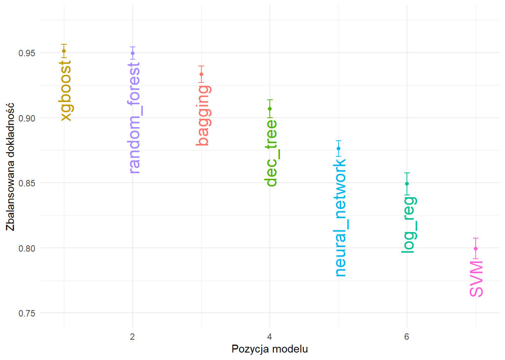

Rysunek 52: Wyniki tuningu i uczenia dla poszczególnych modeli względem metryki zbalansowanej dokładności

Na powyższym wykresie Rysunek 52 można zauważyć, że najlepsze rezultaty osiągają modele drzewiaste, z których najbardziej zbliżone wyniki mają boosting i las losowy ze zbalansowaną dokładnością około 0.95, jako trzeci plasuje się model bagging, z wynikiem około 0.93.

Dla przypomnienia, metrykę zbalansowanej dokładności stosujemy ze względu na brak balansu klas zmiennej zależnej.

## Predykcja na zbiorze testowym

Wyniki trzech najlepszych modeli porównuję za pomocą zbioru testowego. Na początku pobieram najlepsze zestawy parametrów ze względu na metrykę zbalansowanej dokładności.

**Pokaż kod**

```r
# Boosting
boosting_best_results <- bayes_results %>%
  extract_workflow_set_result("xgboost") %>%
  select_best(metric = "bal_accuracy")

# Las Losowy
rf_best_results <- bayes_results %>%
  extract_workflow_set_result("random_forest") %>%
  select_best(metric = "bal_accuracy")

# Bagging
bagging_best_results <- bayes_results %>%
  extract_workflow_set_result("bagging") %>%
  select_best(metric = "bal_accuracy")
```

Następnie dokonuję finalizacji każdego z modeli na podstawie zestawów najlepszych parametrów i wykonuję predykcję na zbiorze testowym.

**Pokaż kod**

```r
# Boosting
boosting_last_fit <- bayes_results %>%
  extract_workflow("xgboost") %>%
  finalize_workflow(boosting_best_results) %>%
  last_fit(split = data_split)

boosting_test_results <- boosting_last_fit %>%
  collect_predictions()

# Las Losowy
rf_last_fit <- bayes_results %>%
  extract_workflow("random_forest") %>%
  finalize_workflow(rf_best_results) %>%
  last_fit(split = data_split)

rf_test_results <- rf_last_fit %>%
  collect_predictions()

# Bagging
bagging_last_fit <- bayes_results %>%
  extract_workflow("bagging") %>%
  finalize_workflow(bagging_best_results) %>%
  last_fit(split = data_split)

bagging_test_results <- bagging_last_fit %>%
  collect_predictions()
```

Na podstawie zgromadzonych wyników wykonuję macierze konfuzji.

**Boosting**

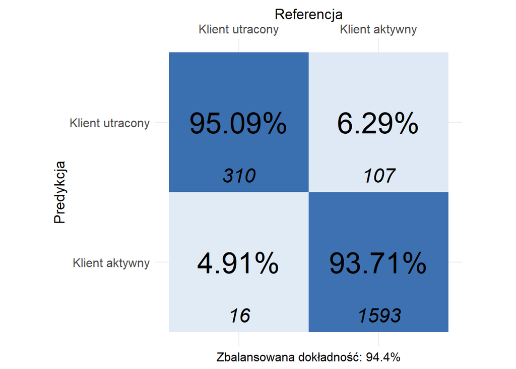

Rysunek 53: Macierz konfuzji dla modelu Boosting

**Las Losowy**

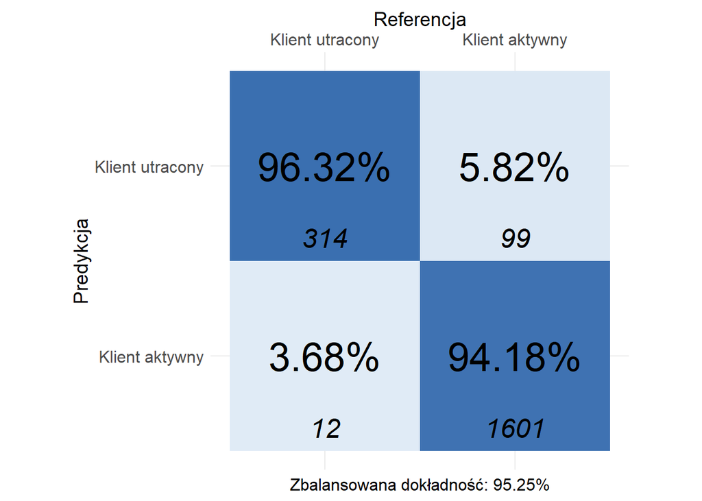

Rysunek 54: Macierz konfuzji dla modelu Lasu Losowego

**Bagging**

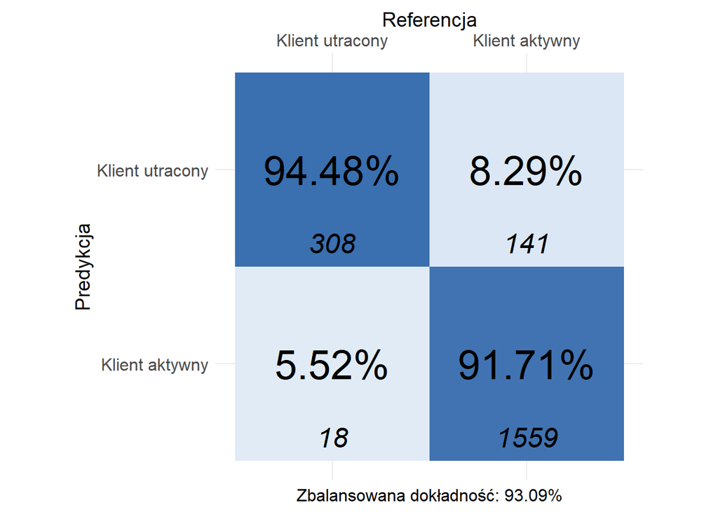

Rysunek 55: Macierz konfuzji dla modelu Bagging

## Istotność predyktorów

Teraz porównam modele pod względem dziesięciu najistotniejszych predyktorów.

**Boosting**

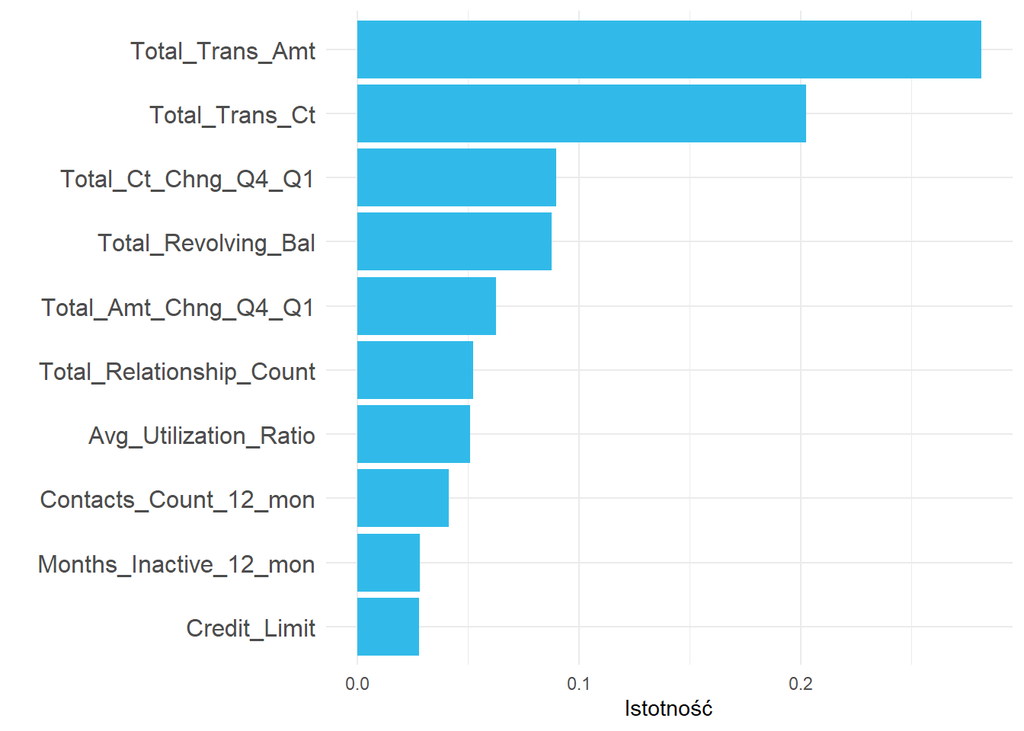

Rysunek 56: Istotność predyktorów dla modelu Boosting

**Las Losowy**

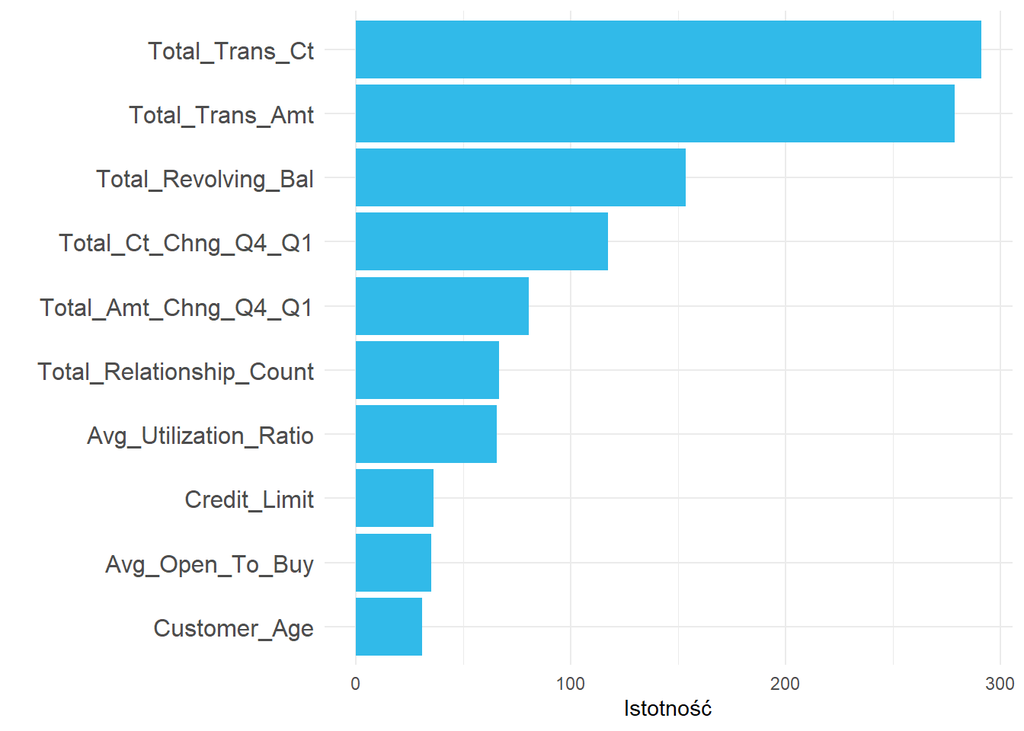

Rysunek 57: Istotność predyktorów dla modelu Lasu Losowego

**Bagging**

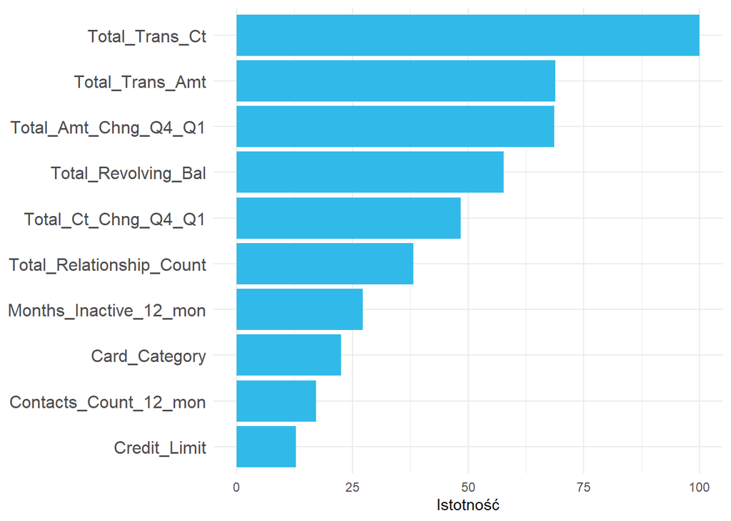

Rysunek 58: Istotność predyktorów dla modelu Bagging

Wszystkie trzy modele jako sześć najistotniejszych predyktorów wybrały zmienne:

- `Total_Trans_Amt`,
- `Total_Trans_Ct`,
- `Total_Ct_Chng_Q4_Q1`,
- `Total_Revolving_Bal`,
- `Total_Amt_Chng_Q4_Q1`,
- `Total_Relationship_Count`

w różnej kolejności, z wyjątkiem zmiennej `Total_Relationship_Count`, która za każdym razem była szósta.

Każdy z modeli jako istotną zmienną wybrał również `Credit_Limit`, a wszystkie współdzielą ze sobą 7 do 9 zmiennych w zależności od zestawienia.

Wśród wyborów zdecydowanie dominują zmienne ilościowe, jedynie model bagging wybrał jako istotną zmienną porządkową `Card_Category`.

# Wnioski

Pod względem skuteczności najlepszy wynik osiągnął model lasu losowego, z dokładnością 95.25%, drugi w kolejności wynik to model boosting, z dokładnością 94.4%, natomiast ostatni, chociaż nadal wysoki rezultat to dokładność 93.09% dla modelu bagging.

Skuteczność tych trzech modeli można ocenić jako przynajmniej dobrą. Ponadto, dokładność zarówno na zbiorze treningowym, jak i testowym jest w każdym przypadku niemal taka sama, co wskazuje na brak przeuczenia modeli.

Co ważne pod względem biznesowym, modele dobrze radzą sobie z poprawnym klasyfikowaniem klientów, którzy rezygnują z posiadania karty kredytowej.

## Bibliografia

Bankier.pl. 2018. “60 Lat Kart Kredytowych. W Tych Krajach Zawojowały Rynek.” https://www.bankier.pl/wiadomosc/60-lat-kart-kredytowych-W-tych-krajach-zawojowaly-rynek-7610590.html.

———. 2024. “Amerykanie Nie Radzą Sobie z Długami. Karty Kredytowe "Zetek" Ledwo Zipią.” https://www.bankier.pl/wiadomosc/Amerykanie-nie-radza-sobie-z-dlugami-Karty-kredytowe-Zetek-ledwo-zipia-8749064.html.

San, Anwar. 2022. “Credit Card Churn Prediction.” *Kaggle*. https://www.kaggle.com/datasets/anwarsan/credit-card-bank-churn/data.

## Przypisy

[^1]: Tidy Modeling with R: A Recommended Preprocessing https://www.tmwr.org/pre-proc-table
[^2]: recipes - Ordering of steps https://recipes.tidymodels.org/articles/Ordering.html